# HGC package manual

Zou Ziheng, Kui Hua

2021-05-02

# 1 Introduction

`HGC` (short for Hierarchical Graph-based Clustering) is a R package for conducting hierarchical clustering on large-scale single-cell RNA-seq (scRNA-seq) data. The key idea is to construct a dendrogram of cells on their shared nearest neighbor (SNN) graph. `HGC` provides functions for building cell graphs and for conducting hierarchical clustering on the graph. Experiments on benchmark datasets showed that `HGC` can reveal the hierarchical structure underlying the data, achieve state-of-the-art clustering accuracy and has better scalability to large single-cell data. For more information, please refer to the preprint of `HGC` on [bioRxiv](https://doi.org/10.1101/2021.02.07.430106).

# 2 Installation

`HGC` could be installed from Bioconductor.

```r
if (!requireNamespace("BiocManager"))
    install.packages("BiocManager")
BiocManager::install("HGC")
```

The users could also get the newest version from Github.

```r
if(!require(devtools))
    install.packages("devtools")
devtools::install_github("XuegongLab/HGC")
```

# 3 Quick Start

## 3.1 Input data

`HGC` takes a matrix as input where row represents cells and column represents features. Preprocessing steps like normalization and dimension reduction are necessary so that the constructed graph can capture the mainfold underlying the single-cell data. We recommend users to follow the standard preprocessing steps in [`Seurat`](https://satijalab.org/seurat/articles/get_started.html). As a demo input, we stored the top 25 principal components of the Pollen dataset ([Pollen et al.](https://www.nature.com/articles/nbt.2967)) in `HGC`. The dataset contains 301 cells with two known labels: labels at the tissue level and the cell line level.

```r
library(HGC)

data(Pollen)
Pollen.PCs <- Pollen[["PCs"]]
Pollen.Label.Tissue <- Pollen[["Tissue"]]
Pollen.Label.CellLine <- Pollen[["CellLine"]]

dim(Pollen.PCs)
```

```
## [1] 301  25
```

```r
table(Pollen.Label.Tissue)
```

```
## Pollen.Label.Tissue
##       blood      dermal      neural pluripotent
##         113          99          65          24
```

```r
table(Pollen.Label.CellLine)
```

```
## Pollen.Label.CellLine
##   2338   2339     BJ   GW16   GW21 GW21+3  hiPSC   HL60   K562   Kera    NPC
##     22     17     37     26      7     17     24     54     42     40     15
```

## 3.2 Run HGC

There are two major steps for conducting the hierarchical clustering with `HGC`: the graph construction step and the dendrogram construction step. `HGC` provides functions for building a group of graphs, including the k-nearest neighbor graph (KNN), the shared nearest neighbor graph (SNN), the continuous k-nearest neighbor graph (CKNN), etc. These graphs are saved as `dgCMatrix` supported by R package `Matrix`. Then `HGC` can directly build a hierarchical tree on the graph. A self-built graph or graphs from other pipelines stored as `dgCMatrix` are also supported.

```r
Pollen.SNN <- SNN.Construction(mat = Pollen.PCs, k = 25, threshold = 0.15)
Pollen.ClusteringTree <- HGC.dendrogram(G = Pollen.SNN)
```

The output of `HGC` is a standard tree following the data structure `hclust()` in R package `stats`. The tree can be cut into specific number of clusters with the function `cutree`.

```r
cluster.k5 <- cutree(Pollen.ClusteringTree, k = 5)
```

## 3.3 Visualization

With various published methods in R, results of `HGC` can be visualized easily. Here we use the R package `dendextend` as an example to visualize the results on the Pollen dataset. The tree has been cut into five clusters. And for a better visualization, the height of the tree has been log-transformed.

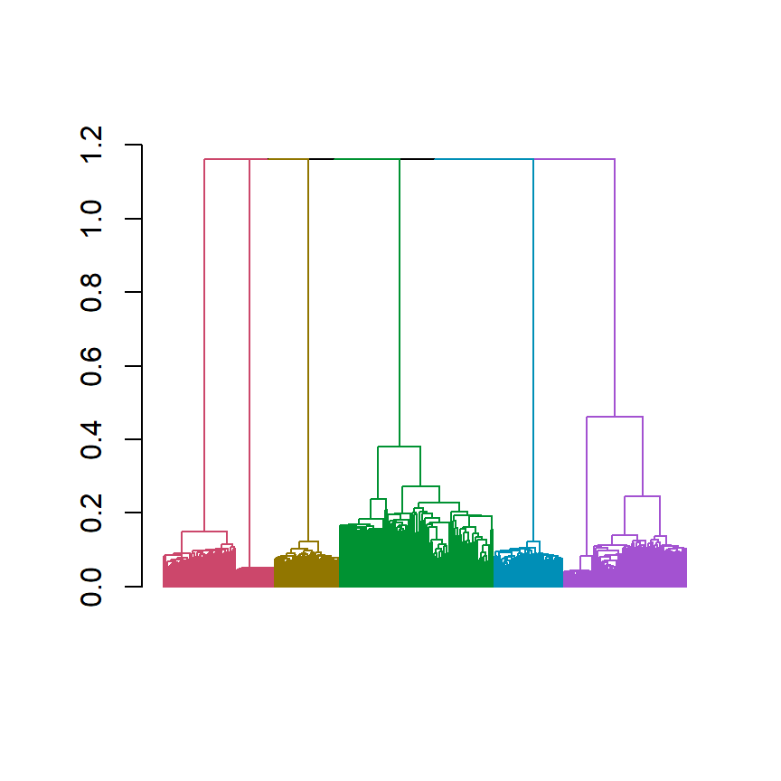

```
## [1] 1
```

```r
Pollen.ClusteringTree$height = log(Pollen.ClusteringTree$height + 1)
Pollen.ClusteringTree$height = log(Pollen.ClusteringTree$height + 1)

HGC.PlotDendrogram(tree = Pollen.ClusteringTree,
                    k = 5, plot.label = FALSE)
```

We can also add a colour bar of the known label under the dendrogram as a comparison of the achieved clustering results.

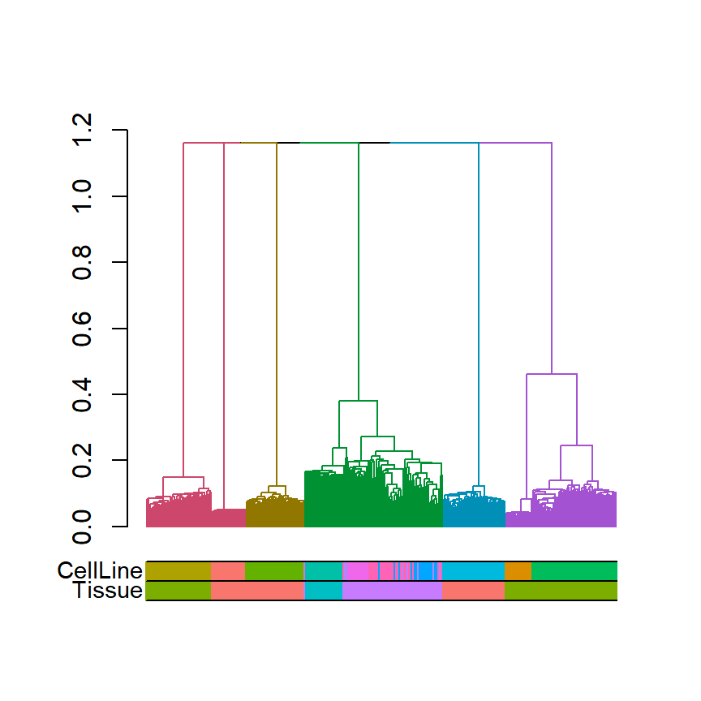

```
## [1] 1
```

```r
Pollen.labels <- data.frame(Tissue = Pollen.Label.Tissue,
                            CellLine = Pollen.Label.CellLine)
HGC.PlotDendrogram(tree = Pollen.ClusteringTree,
                    k = 5, plot.label = TRUE,
                    labels = Pollen.labels)
```

## 3.4 Ealuation of the clustering results

For datasets with known labels, the clustering results of `HGC` can be evaluated by comparing the consistence between the known labels and the achieved clusters. Adjusted Rand Index (ARI) is a wildly used statistics for this purpose. Here we calculate the ARIs of the clustering results at different levels of the dendrogram with the two known labels.

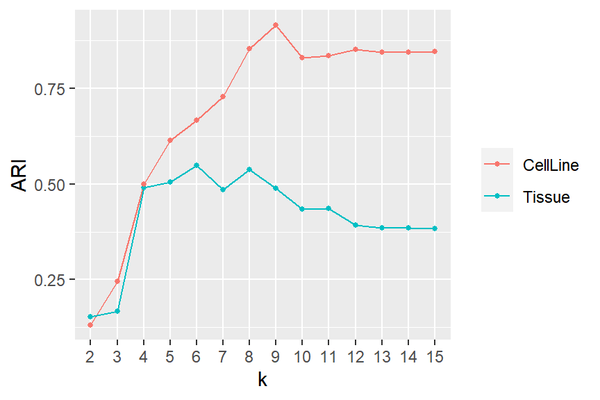

```r
ARI.mat <- HGC.PlotARIs(tree = Pollen.ClusteringTree,
                        labels = Pollen.labels)
```

# 4 Time complexity analysis of HGC

Our work shows that the dendrogram construction in `HGC` has a linear time complexity. For advanced users, `HGC` provides functions to conduct time complexity analysis on their own data. The construction of the dendrogram is a recursive procedure of two steps: 1.finding the nearest neighbour pair, 2. merge the node pair and update the graph. For different data structures of graph, there's a trade-off between the time consumptions of the two steps. Generally speaking, storing more information about the graph makes it faster to find the nearest neighbour pair (step 1) but slower to update the graph (step 2). We have experimented serval datasets and chosen the best data structure for the overall efficiency.

The key parameters related to the time consumptions of the two steps are the length of the nearest neighbor chains and the number of nodes needed to be updated in each iteration, respectively (for more details, please refer to our [preprint](https://doi.org/10.1101/2021.02.07.430106)).`HGC` provides functions to record and visualize these parameters.

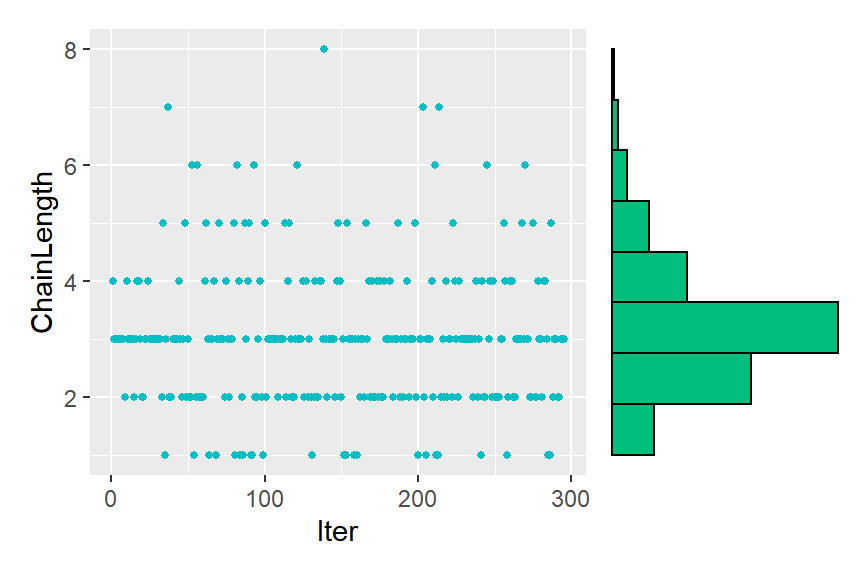

```
## [1] 1
```

```r
Pollen.ParameterRecord <- HGC.parameter(G = Pollen.SNN)

HGC.PlotParameter(Pollen.ParameterRecord, parameter = "CL")
```

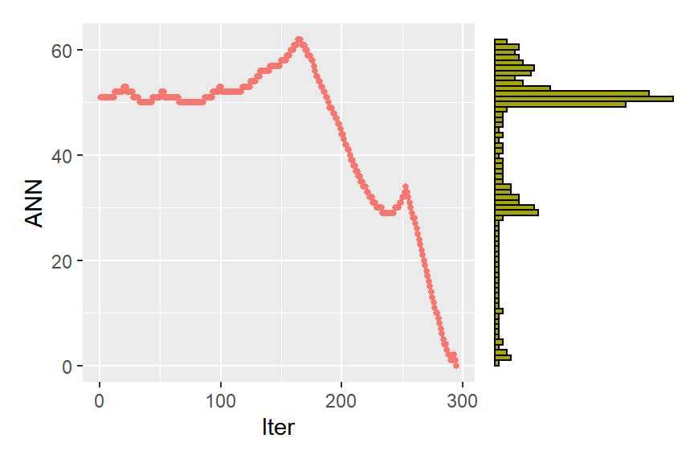

```
## [1] 1
```

```r
HGC.PlotParameter(Pollen.ParameterRecord, parameter = "ANN")
```